# 데이터 과학을 위한 저작도구: Computational Documents

R마크다운 글꼴(font)

[Tidyverse Korea](https://www.facebook.com/groups/tidyverse/)

2020-05-27

# 1 글꼴

## 1.1 글꼴 확인

맥OS의 경우 글꼴이 사용자 및 시스템에 따라 설치된 경로가 다르다.

- `/Library/Fonts`: 컴퓨터를 이용하는 모든 사용자(계정)에게 적용되는 글꼴
- `~/Library/Fonts`: 현재 로그인된 사용자(계정)만 적용가능한 글꼴

터미널에서 `fc-list` 명령어를 통해 “나눔손글씨(Nanum Pen Script)” 폰트가 설치되었는지 찾아본다.

```bash
fc-list | grep -v statkclee | grep "Nanum Pen Script"
```

```
/Library/Fonts/NanumPen.otf: Nanum Pen Script OTF,나눔손글씨 펜 OTF:style=Regular
```

## 1.2 R에서 확인

두번째 단계로 R에서 “나눔손글씨” 폰트가 설치되었는지 확인한다. `font_import()` 함수를 사용해서 시스템에 설치된 폰트를 R에서 사용할 수 있도록 등록한다. 등록된 폰트는 `loadfonts()` 함수를 사용해서 그래프에 우선 적용한다.

```r
library(tidyverse)
library(extrafont)
# 폰트 설치
font_import(pattern = "Nanum")
```

```
Importing fonts may take a few minutes, depending on the number of fonts and the speed of the system.
Continue? [y/n]
```

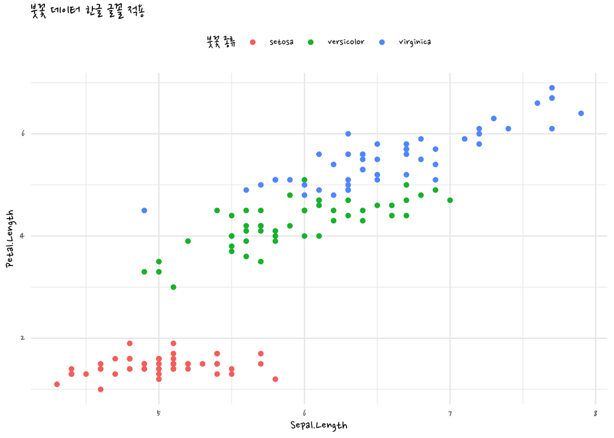

```r
# 폰트 가져오기
loadfonts()

iris %>%
  ggplot(aes(x=Sepal.Length, y=Petal.Length, color=Species)) +
    geom_point()+
    labs(title="붓꽃 데이터 한글 글꼴 적용", color="붓꽃 종류") +
    theme_minimal(base_family = "Nanum Pen Script") +
    theme(legend.position = "top")
```

# 2 R 글꼴에 대한 기본기

- [데이터 시각화 : R 그래프/코딩 글꼴(font)](https://statkclee.github.io/viz/viz-r-font.html)

# 3 R마크다운 문서

```r
---
title: "R마크다운 글꼴(font)"
subtitle: "문서 한글 글꼴 적용"
author:
    name: "[Tidyverse Korea](https://www.facebook.com/groups/tidyverse/)"
date: "`r Sys.Date()`"
output:
  html_document:
    toc: yes
    toc_float: true
    highlight: tango
    code_folding: show
    number_section: true
    self_contained: true
editor_options:
  chunk_output_type: console
---

<style>
body {
  font-family: Nanum Pen Script;
}
</style>

# 붓꽃 데이터

붓꽃 데이터는 사랑입니다.
```

뜨게질(knit)하여 컴파일 시키게 되면 다음과 같이 폰트가 문서 전체에 적용된 것을 확인할 수 있다.

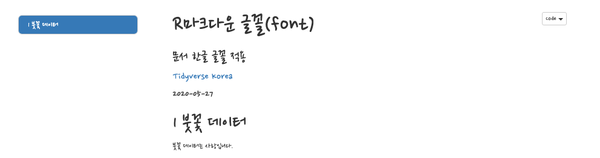

```r
library(webshot2)

webshot("tutorial/fonts/documents.html", "fig/fonts-document.png")
```

# 4 한걸음 더 들어갑니다

`rmarkdown-advanced.Rmd` 문서를 `fonts.css`를 서식파일로 지정해서 수준별 제목 및 표에 대한 폰트 및 배경 등을 따로 정의해서 문서를 생성시킬 수 있다.

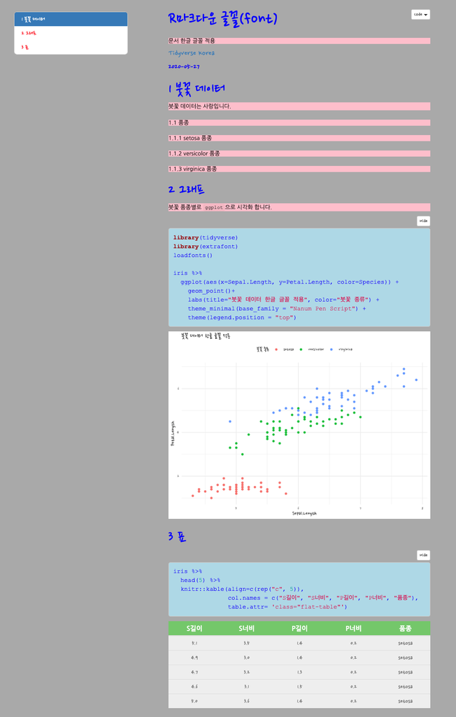

```r
webshot2::webshot("tutorial/fonts/documents-advanced.html", "fig/rmarkdown-advaned2.png")
```

상기 결과를 얻기 위한 `rmarkdown-advanced.Rmd` 문서와 `fonts.css` 서식 파일은 다음과 같다.

````markdown
---
title: "R마크다운 글꼴(font)"
subtitle: "문서 한글 글꼴 적용"
author:
    name: "[Tidyverse Korea](https://www.facebook.com/groups/tidyverse/)"
date: "2020-05-27"
output:
  html_document:
    css: fonts.css
    toc: yes
    toc_float: true
    code_folding: show
    number_section: true
    self_contained: true
---

# 붓꽃 데이터

붓꽃 데이터는 사랑입니다.

## 품종

### setosa 품종

### versicolor 품종

### virginica 품종

# 그래프

붓꽃 품종별로 `ggplot`으로 시각화 합니다.


```r
library(tidyverse)
library(extrafont)
loadfonts()

iris %>%
  ggplot(aes(x=Sepal.Length, y=Petal.Length, color=Species)) +
    geom_point()+
    labs(title="붓꽃 데이터 한글 글꼴 적용", color="붓꽃 종류") +
    theme_minimal(base_family = "Nanum Pen Script") +
    theme(legend.position = "top")
```

# 표


```r
iris %>%
  head(5) %>%
  knitr::kable(align=c(rep("c", 5)),
               col.names = c("S길이", "S너비", "P길이", "P너비", "품종"),
               table.attr= 'class="flat-table"')
```
````

`fonts.css` 서식 파일은 다음과 같다.

```markdown
/* ------------- HTML ------------- */

body {
  color: blue;
  font-family: Nanum Pen Script;
  background-color: darkgray;
}

pre {
  color: blue;
  font-family: NanumBarunpen;
  background-color: lightblue;
}

#TOC {
  color: red;
  font-family: Nanum Pen Script;
  background-color: gray;
}

header {
  color: black;
  font-family: Nanum Pen Script;
  background-color: green;
  opacity: 0.5;
  font-family: NanumGothicBold;
}

h2,h3,p {
  color: black;
  background-color: pink;
  font-family: NanumGothic;
  font-size: 12px;
}

/* ------------- 표 ------------- */

.flat-table {
  display: block;
  font-family: NanumGothicBold;
  font-size: 125%;
  overflow: auto;
  width: auto;
}

th {
  font-family: NanumGothicBold;
  background-color: rgb(112, 196, 105);
  color: white;
  font-weight: normal;
  padding: 20px 30px;
  text-align: center;
}

td {
  background-color: rgb(238, 238, 238);
  color: rgb(111, 111, 111);
  padding: 20px 30px;
}
```